# linc-Brn1a KO vs WT (Adult)

## Differential Splicing

### Differential Isoforms between conditions

Per isoform difference between conditions:

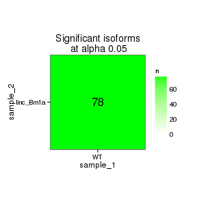

These isoforms are:

|  | isoAnnot$gene_short_name |
| --- | --- |
| 1 | Rec8 |
| 2 | Arrdc2 |
| 3 | Fosb |
| 4 | Hif3a |
| 5 | Dio2 |
| 6 | Mertk |
| 7 | Hspa8 |
| 8 | Vip |
| 9 | Fabp7 |
| 10 | Cpm |
| 11 | Tns3 |
| 12 | Btg2 |
| 13 | Xbp1 |
| 14 | Atp2a3 |
| 15 | Fos |
| 16 | Arc |
| 17 | Zbtb20 |
| 18 | Sdf2l1 |
| 19 | Nr4a1 |
| 20 | Cdkn1a |
| 21 | Sik1 |
| 22 | Xdh |
| 23 | Atp6v0c |
| 24 | Dusp1 |
| 25 | Fkbp5 |
| 26 | Il33 |
| 27 | Pdia4 |
| 28 | Paqr8 |
| 29 | Tfcp2l1 |
| 30 | Hspa5 |
| 31 | Cyr61 |
| 32 | Alad |
| 33 | Slc2a1 |
| 34 | Mfsd2a |
| 35 | Ago3 |
| 36 | Map3k6 |
| 37 | Ccnl2 |
| 38 | Adipor2 |
| 39 | Pglyrp1 |
| 40 | Hddc3 |
| 41 | Tsc22d3 |
| 42 | Cryab |
| 43 | Kdm4a |
| 44 | Ndn |
| 45 | Vps8 |
| 46 | Igsf9b |
| 47 | Cbl |
| 48 | Anln |
| 49 | Kirrel2 |
| 50 | Egr2 |
| 51 | Smim3 |
| 52 | Egr1 |
| 53 | Hdhd3 |
| 54 | Eltd1 |
| 55 | Daam2 |
| 56 | Dmtf1 |
| 57 | Npas4 |
| 58 | Ezr |
| 59 | Jun |
| 60 | Junb |
| 61 | Ier2 |
| 62 | Per2 |
| 63 | Kdm5d |
| 64 | Usp31 |
| 65 | Sepp1 |
| 66 | Zbtb16 |
| 67 | Ddx3y |
| 68 | Ahnak |
| 69 | Klhl9 |
| 70 | Egr4 |
| 71 | Gm7292 |
| 72 | Xist |
| 73 | Cdr1 |
| 74 | Malat1 |
| 75 | Gm6472 |
| 76 | Gm26924 |

Gene-level DE isoform heatmap

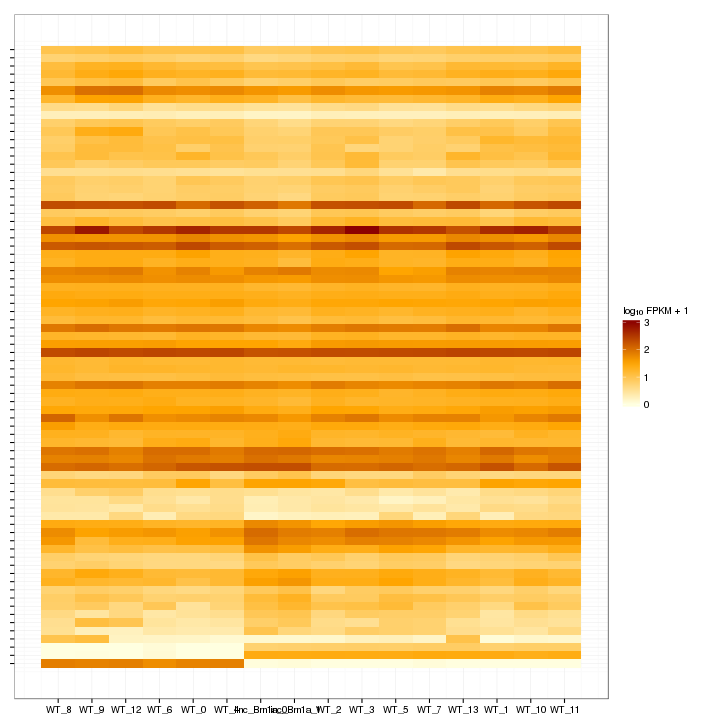

Isoform foldchange heatmap by isoform:

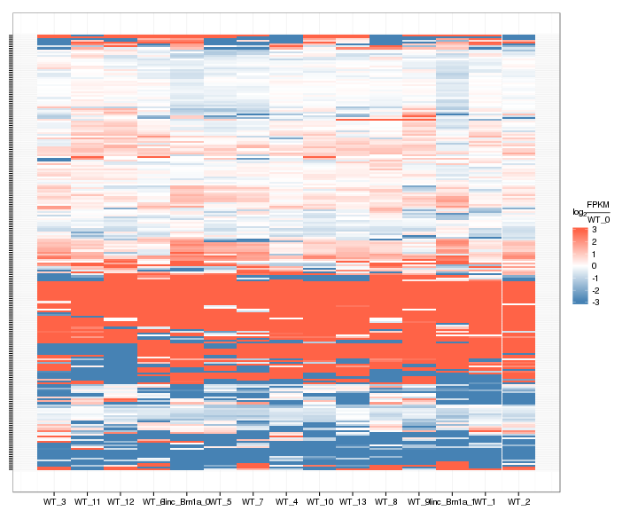

### Differential Splicing between conditions

(eval false for first pass)

# Gene/Pathway Analysis

## GSEA

Enrichment and zscores are calculated based on expression in KO vs WT (fpkmKO/fpkmWT), so genes that are down regulated in KO are shown in blue, while upregulation is shown in red.

KO/WT Blue = down in KO Red = Up in KO

Biocarta enrichment:

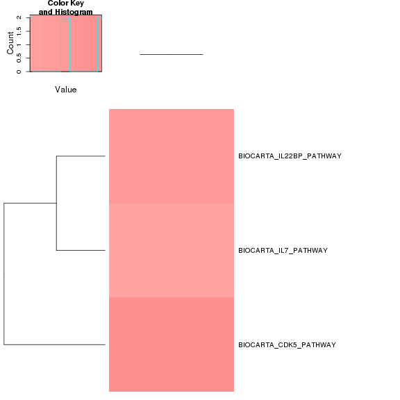

Biocarta zscore:

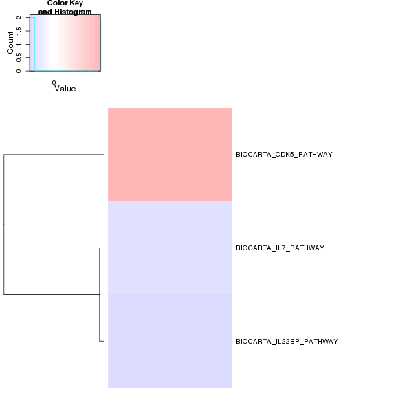

Reactome enrichment:

[output not shown]

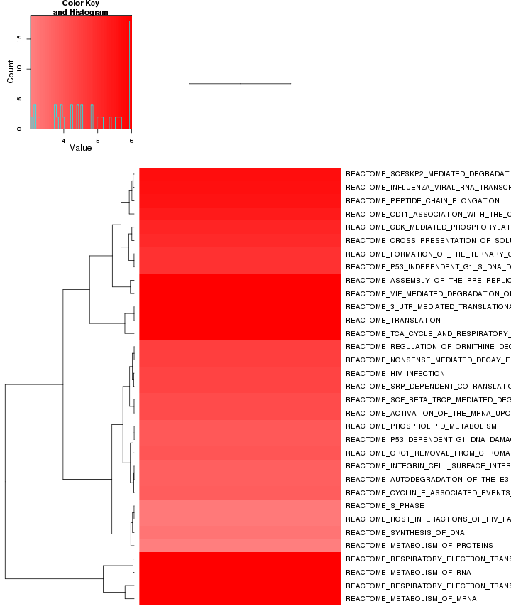

Reactome zscore:

[output not shown]

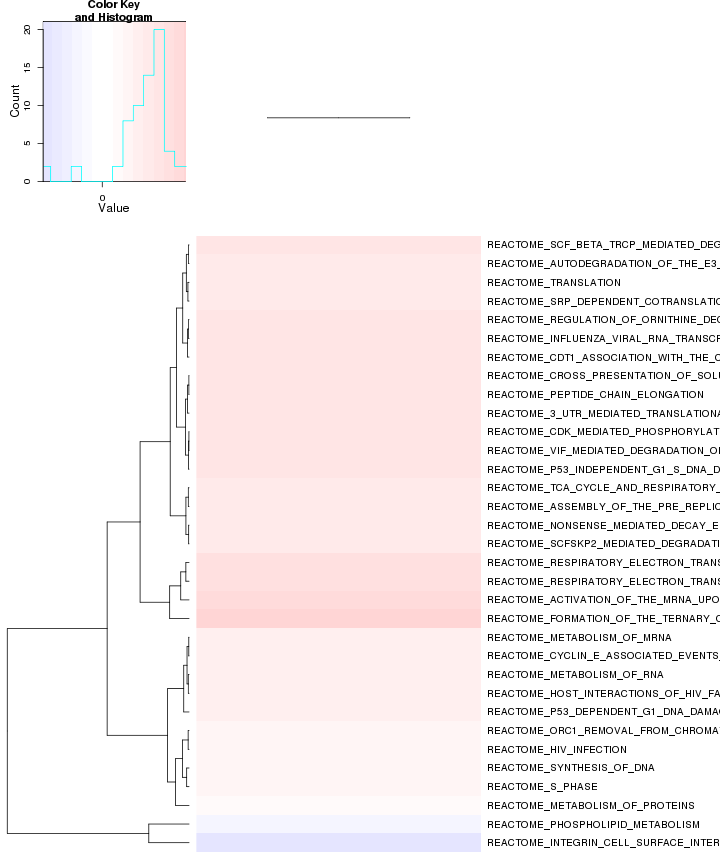

Kegg enrichment:

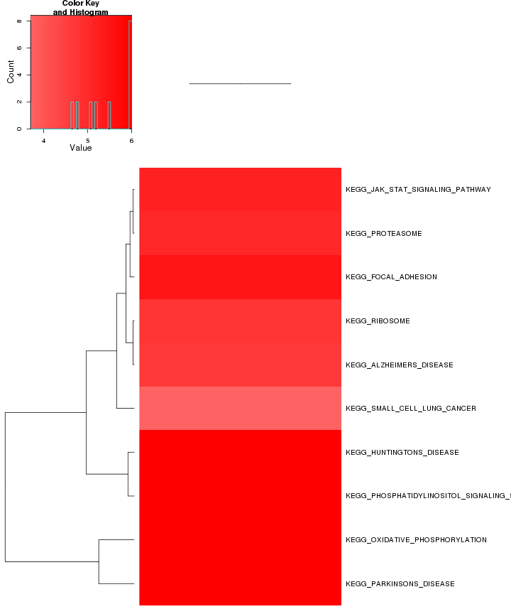

Kegg zscore:

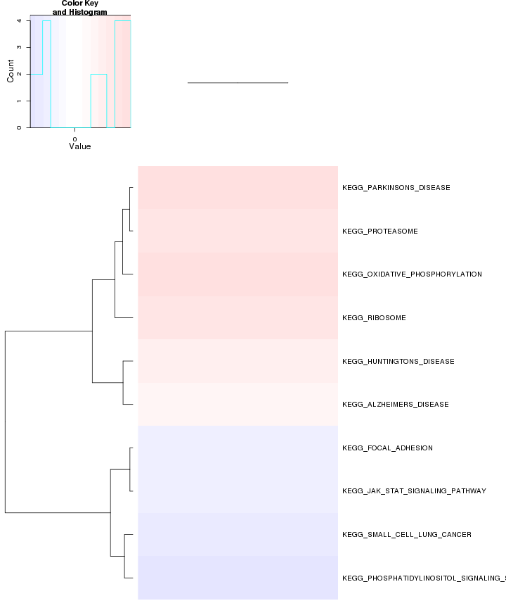

Interneuron enrichment:

[output not shown]

[figure not shown]

Interneuron zscore:

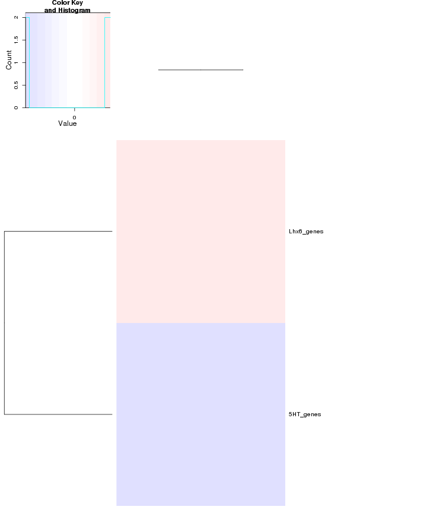

Oncogene enrichment:

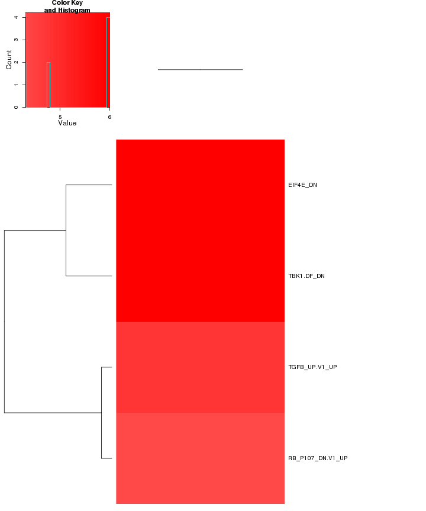

Oncogene zscore:

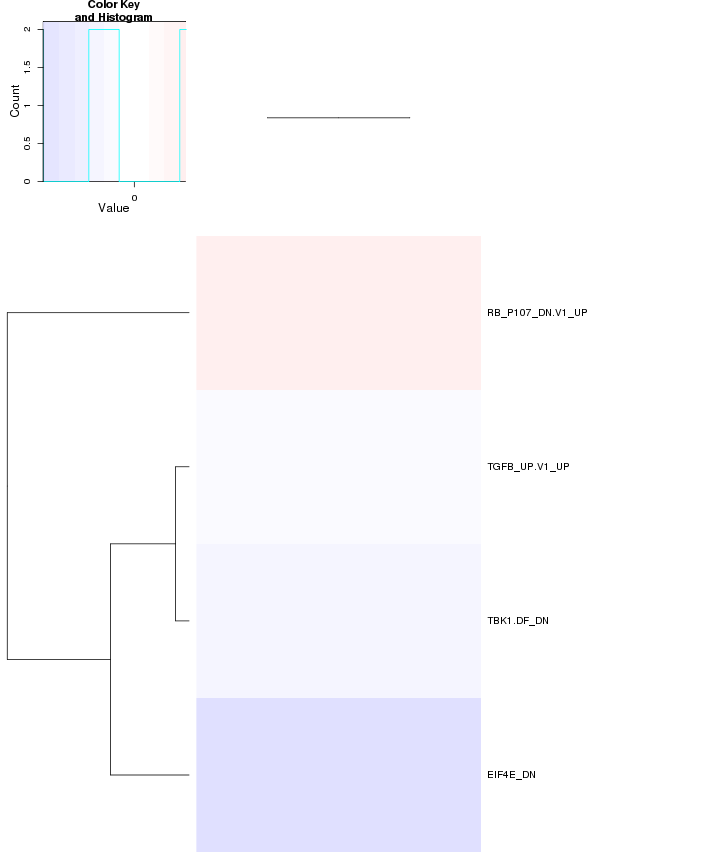

Immuno enrichment:

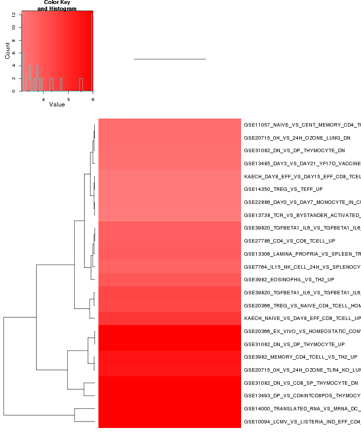

Immuno zscore:

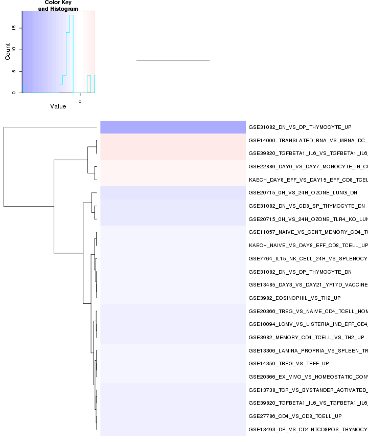

TF enrichment:

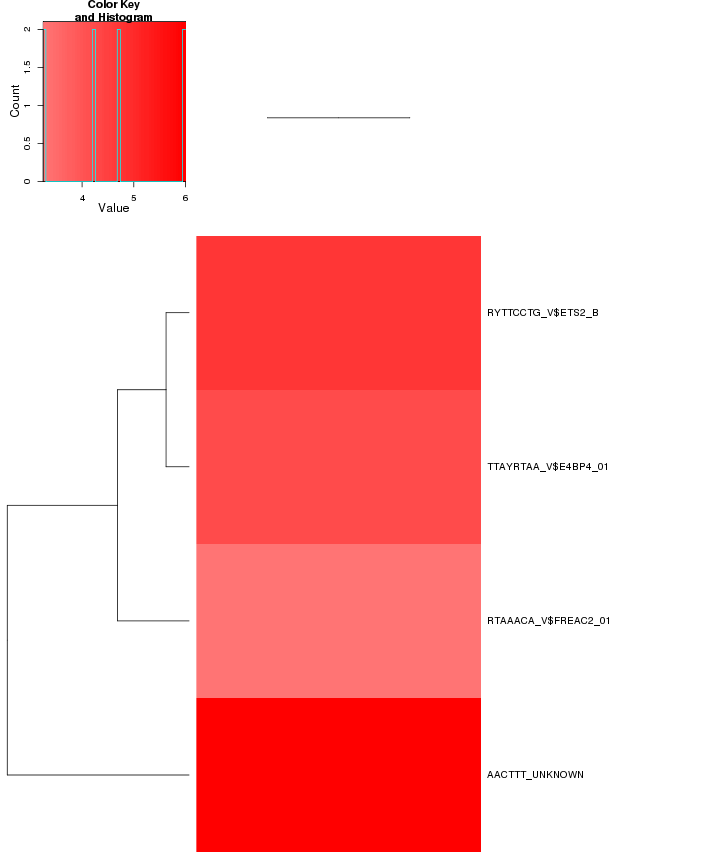

TF zscore:

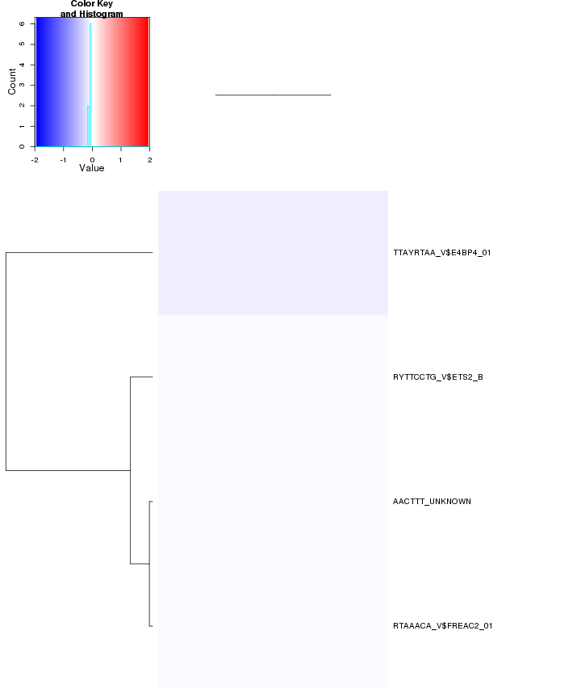

## GO enrichment

Cluster profiler used to call enichments of significantly differentially regulated genes that map to Entrez IDs.

[output not shown]

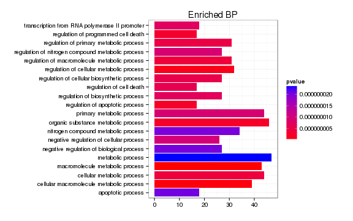

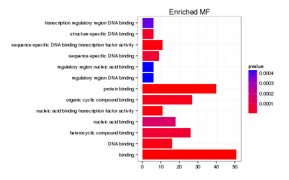

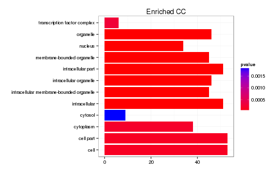

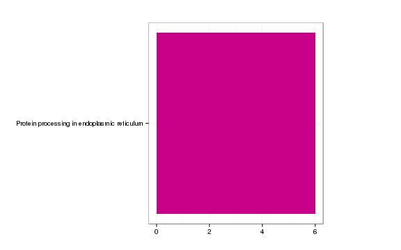

[output not shown]

### Enrichment or depletion for stage-specific cell cycle markers

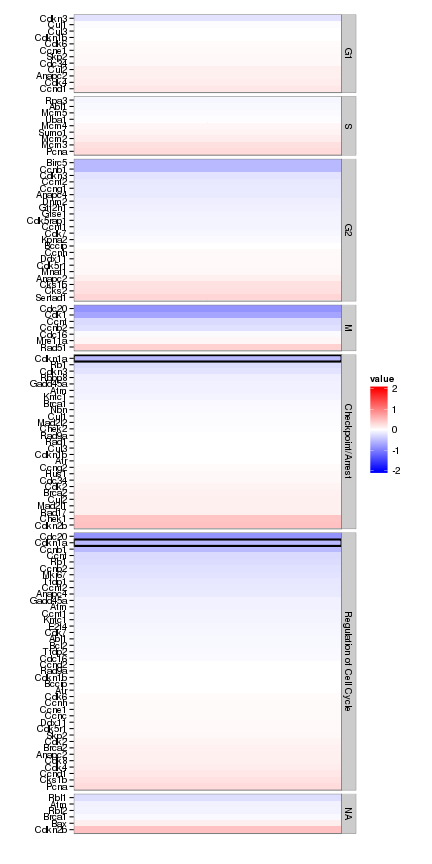

### Enrichment or depletion for markers of specific cortical layers

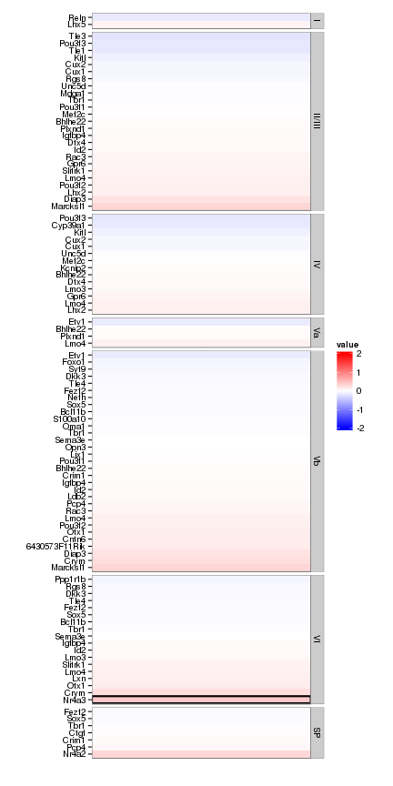

### Enrichment or depletion for specific neural cell types

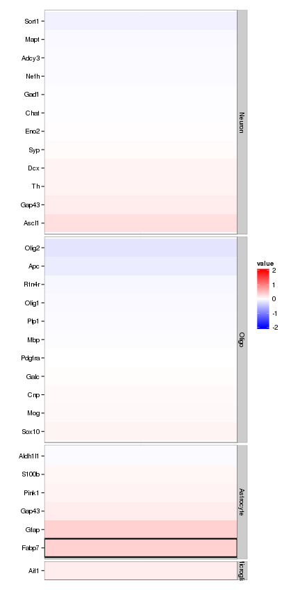

### Enrichment or Depletion of neural differentiation markers

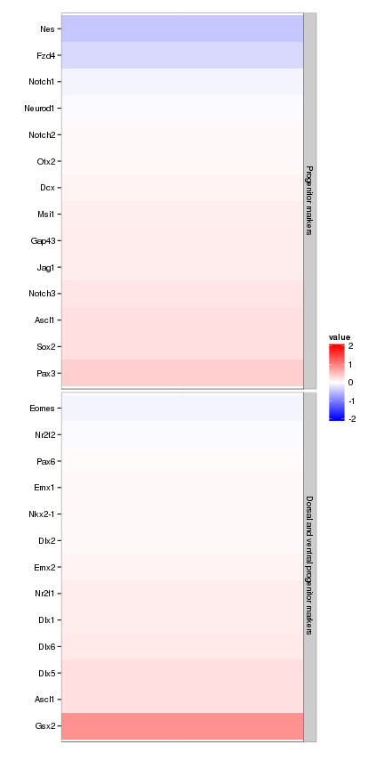

# Cis vs Trans (locally)

log2 Foldchange and test statistic are calculated with the ratio of fpkm(KO)/fpkm(WT), thus the test_stat is positive if a gene is higher in the KO and negative if a gene has lower expression in the KO

The pvalue for 0 genes significantly regulated in a region this size is: 1

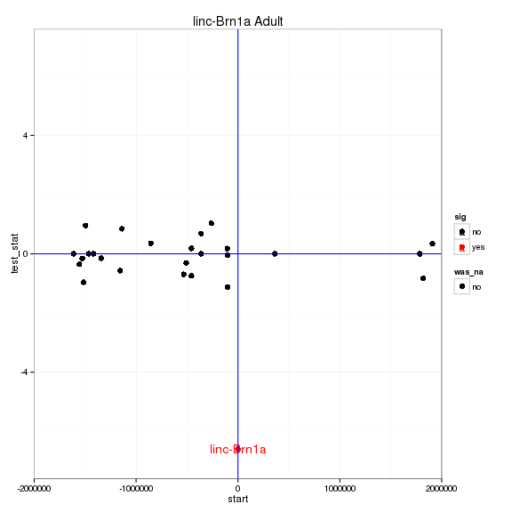

# Notes

## Samples used are:

|  | 10 |
| --- | --- |
| 1 | JR729 |
| 2 | JR728 |
| 3 | JR796 |
| 4 | JR797 |
| 5 | JR740 |
| 6 | JR800 |
| 7 | JR827 |
| 8 | JR778 |
| 9 | JR734 |
| 10 | JR802 |
| 11 | JR803 |
| 12 | JR735 |
| 13 | JR785 |
| 14 | JR781 |
| 15 | JR730 |
| 16 | JR837 |

## Replicates

|  | file | sample_name | replicate | rep_name | total_mass | norm_mass | internal_scale | external_scale |
| --- | --- | --- | --- | --- | --- | --- | --- | --- |
| 1 | /n/rinn_data1/seq/lgoff/Projects/BrainMap/data/quants/JR729/abundances.cxb | WT | 0 | WT_0 | 26334400.00 | 33756400.00 | 0.78 | 1.00 |
| 2 | /n/rinn_data1/seq/lgoff/Projects/BrainMap/data/quants/JR728/abundances.cxb | WT | 1 | WT_1 | 20329200.00 | 33756400.00 | 0.60 | 1.00 |
| 3 | /n/rinn_data1/seq/lgoff/Projects/BrainMap/data/quants/JR796/abundances.cxb | WT | 2 | WT_2 | 34089000.00 | 33756400.00 | 1.00 | 1.00 |
| 4 | /n/rinn_data1/seq/lgoff/Projects/BrainMap/data/quants/JR797/abundances.cxb | WT | 3 | WT_3 | 28103300.00 | 33756400.00 | 0.82 | 1.00 |
| 5 | /n/rinn_data1/seq/lgoff/Projects/BrainMap/data/quants/JR740/abundances.cxb | WT | 4 | WT_4 | 35808200.00 | 33756400.00 | 1.06 | 1.00 |
| 6 | /n/rinn_data1/seq/lgoff/Projects/BrainMap/data/quants/JR800/abundances.cxb | WT | 5 | WT_5 | 37012200.00 | 33756400.00 | 1.10 | 1.00 |
| 7 | /n/rinn_data1/seq/lgoff/Projects/BrainMap/data/quants/JR827/abundances.cxb | WT | 6 | WT_6 | 27786600.00 | 33756400.00 | 0.83 | 1.00 |
| 8 | /n/rinn_data1/seq/lgoff/Projects/BrainMap/data/quants/JR778/abundances.cxb | WT | 7 | WT_7 | 39541900.00 | 33756400.00 | 1.18 | 1.00 |
| 9 | /n/rinn_data1/seq/lgoff/Projects/BrainMap/data/quants/JR734/abundances.cxb | WT | 8 | WT_8 | 34480600.00 | 33756400.00 | 1.04 | 1.00 |
| 10 | /n/rinn_data1/seq/lgoff/Projects/BrainMap/data/quants/JR802/abundances.cxb | WT | 9 | WT_9 | 45467400.00 | 33756400.00 | 1.33 | 1.00 |
| 11 | /n/rinn_data1/seq/lgoff/Projects/BrainMap/data/quants/JR803/abundances.cxb | WT | 10 | WT_10 | 52130400.00 | 33756400.00 | 1.54 | 1.00 |
| 12 | /n/rinn_data1/seq/lgoff/Projects/BrainMap/data/quants/JR735/abundances.cxb | WT | 11 | WT_11 | 34994400.00 | 33756400.00 | 1.04 | 1.00 |
| 13 | /n/rinn_data1/seq/lgoff/Projects/BrainMap/data/quants/JR785/abundances.cxb | WT | 12 | WT_12 | 34173600.00 | 33756400.00 | 1.00 | 1.00 |
| 14 | /n/rinn_data1/seq/lgoff/Projects/BrainMap/data/quants/JR781/abundances.cxb | WT | 13 | WT_13 | 41538900.00 | 33756400.00 | 1.24 | 1.00 |
| 15 | /n/rinn_data1/seq/lgoff/Projects/BrainMap/data/quants/JR730/abundances.cxb | linc_Brn1a | 0 | linc_Brn1a_0 | 24947000.00 | 33756400.00 | 0.74 | 1.00 |
| 16 | /n/rinn_data1/seq/lgoff/Projects/BrainMap/data/quants/JR837/abundances.cxb | linc_Brn1a | 1 | linc_Brn1a_1 | 38529800.00 | 33756400.00 | 1.16 | 1.00 |

## Run Info

[output not shown]